# Coursera/Reproducible Research Project 1

Richard Ferro

12/28/2018

## Loading and preprocessing the data

Reading the data into activity data frame.

```r
activity <- read.csv("activity.csv", na.strings="NA")
head(activity)
```

```
##   steps       date interval
## 1    NA 2012-10-01        0
## 2    NA 2012-10-01        5
## 3    NA 2012-10-01       10
## 4    NA 2012-10-01       15
## 5    NA 2012-10-01       20
## 6    NA 2012-10-01       25
```

Process/transform the data into a format suitable analysis.

```r
activity$date <- as.Date(activity$date)
act <- subset(activity, !is.na(activity$steps))
```

## The mean total number of steps taken per day.

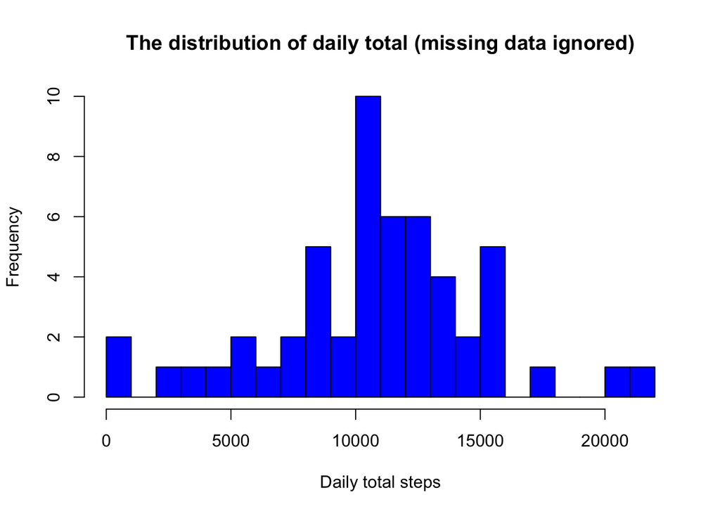

```r
dailysum <- tapply(act$steps, act$date, sum, na.rm=TRUE, simplify=TRUE)
dailysum <- dailysum[!is.na(dailysum)]

hist(x=dailysum,
     col="blue",
     breaks=25,
     xlab="Daily total steps",
     ylab="Frequency",
     main="The distribution of daily total (missing data ignored)")
```

```r
rmean <- mean(dailysum)
rmedian <- median(dailysum)
```

The mean is 1.076618910^{4} and the median is 10765

## The average daily activity pattern.

Calculate average steps for each interval for all days. Plot the Average Number Steps per Day by Interval. Find interval with most average steps.

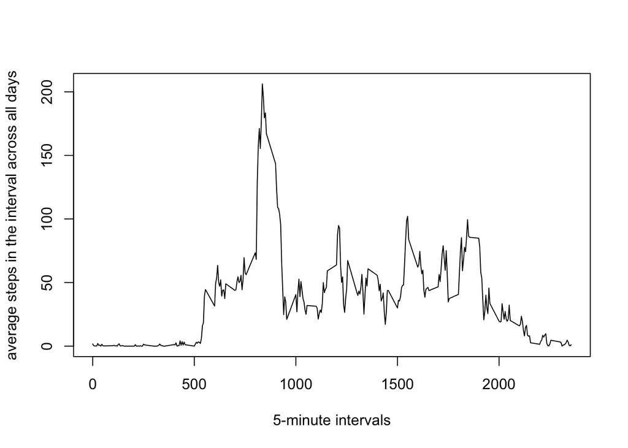

```r
a <- tapply(act$steps, act$interval, mean, na.rm=TRUE, simplify=TRUE)
ActivityAvg <- data.frame(interval=as.integer(names(a)), avg=a)

with(ActivityAvg,
     plot(interval,
          avg,
          type="l",
          xlab="5-minute intervals",
          ylab="average steps in the interval across all days"))
```

```r
 max_steps <- max(ActivityAvg$avg)
 ival <- ActivityAvg[ActivityAvg$avg == max_steps, ]
```

The 5-minute interval, on average across all the days in the data set, containing the maximum number of steps is 835, 206.1698113.

## Impute missing values. Compare imputed to non-imputed data.

Report the total number of missing values in the dataset (i.e. the total number of rows with NAs)

```r
sm <- sum(is.na(activity$steps))
```

The original data set has 2304 rows with missing data. A simple strategy for filling in all of the missing values in the dataset. If a 5-minute interval has missing value, then the mean for that 5-minute interval. A new data frame is created, activity1, that is equal to the original dataset but with the missing data filled in (using mean for that interval for imputation).

```r
activity1 <- activity
nx <- is.na(activity1$steps)
a <- tapply(act$steps, act$interval, mean, na.rm=TRUE, simplify=TRUE)
activity1$steps[nx] <- a[as.character(activity1$interval[nx])]
```

Make a histogram of the total number of steps taken each day.

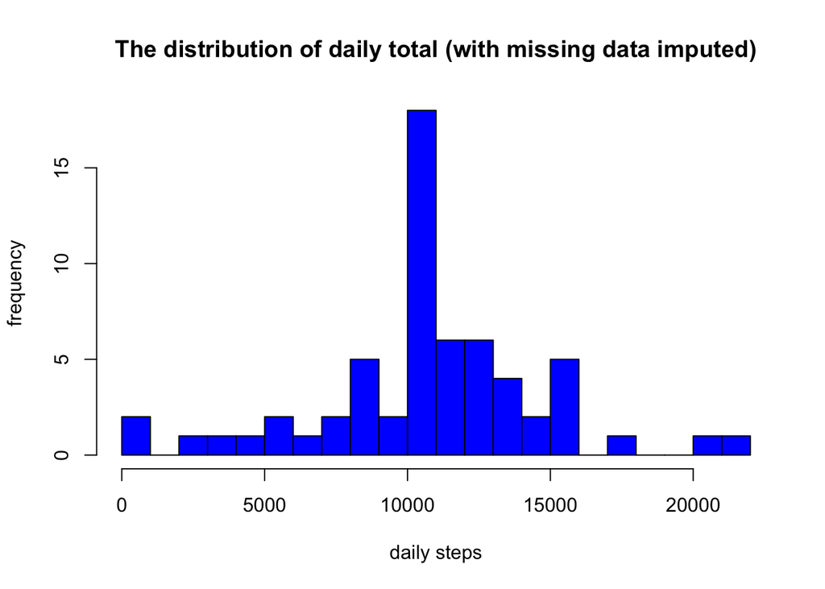

```r
new_dailysum <- tapply(activity1$steps, activity1$date, sum, na.rm=TRUE,
                       simplify=TRUE)
hist(x=new_dailysum,
     col="blue",
     breaks=20,
     xlab="daily steps",
     ylab="frequency",
     main="The distribution of daily total (with missing data imputed)")
```

Calculate and report the mean and median total number of steps taken per day.

```r
imp_mean <- mean(new_dailysum)
imp_median <- median(new_dailysum)
```

The imputed mean is 1.076618910^{4} and the imputed median is 1.076618910^{4}

Calculate difference between imputed and non-imputed data.

```r
mean_diff <- imp_mean - rmean
med_diff <- imp_median - rmedian
```

The difference in the means 0. The difference in the medians 1.1886792.

## Differences in activity patterns between weekdays and weekends.

```r
is_weekday <- function(d) {
  wd <- weekdays(d)
  ifelse (wd == "Saturday" | wd == "Sunday", "weekend", "weekday")
}

wx <- sapply(activity1$date, is_weekday)
activity1$wk <- as.factor(wx)
head(activity1)
```

```
##       steps       date interval      wk
## 1 1.7169811 2012-10-01        0 weekday
## 2 0.3396226 2012-10-01        5 weekday
## 3 0.1320755 2012-10-01       10 weekday
## 4 0.1509434 2012-10-01       15 weekday
## 5 0.0754717 2012-10-01       20 weekday
## 6 2.0943396 2012-10-01       25 weekday
```

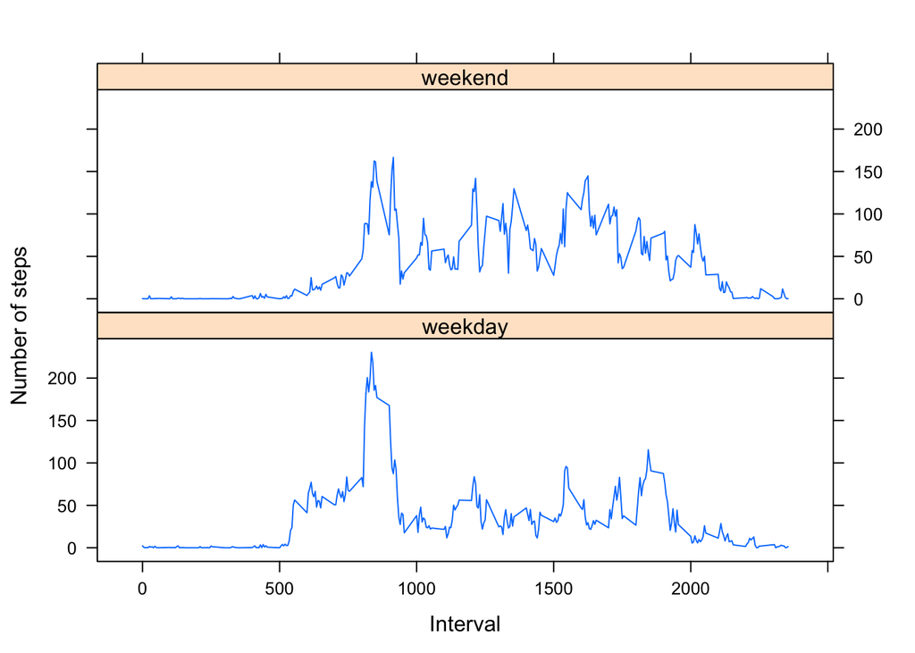

```r
wk_act <- aggregate(steps ~ wk+interval, data=activity1, FUN=mean)

library(lattice)

xyplot(steps ~ interval | factor(wk),
       layout = c(1, 2),
       xlab="Interval",
       ylab="Number of steps",
       type="l",
       lty=1,
       data=wk_act)
```